# Data Organization with Excel 2

# Pivot Chart Continued

1. Let’s try the Pivot Table again.
2. Delete the Sheet with the old Pivot Chart. Go back to the worksheet with the flights data. Click on the small triangle to the left of column `A` and above row `1`. This should highlight the entire dataset.

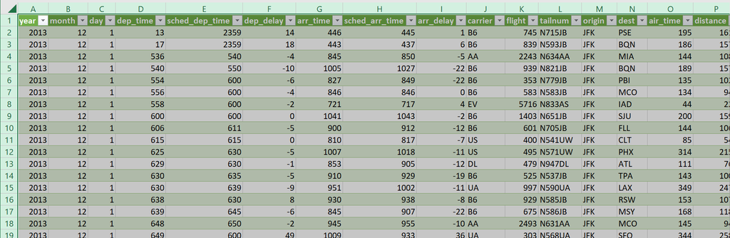

3. Select the Insert tab and click on PivotChart.
4. Drag `sdd_bin` to the AXIS box and `dep_delay` to the VALUES box. Make sure the `dep_delay` is shown as Average.

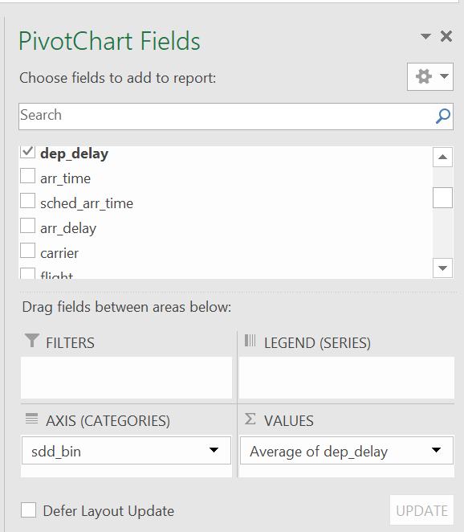

5. Your chart should look like this.

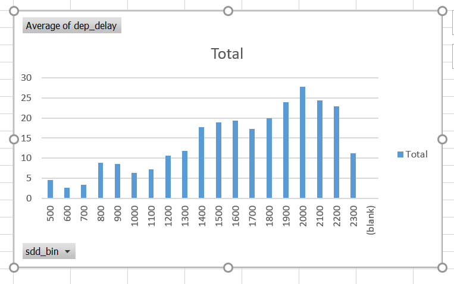

6. Right-click on the body of the chart and change the chart type to line.

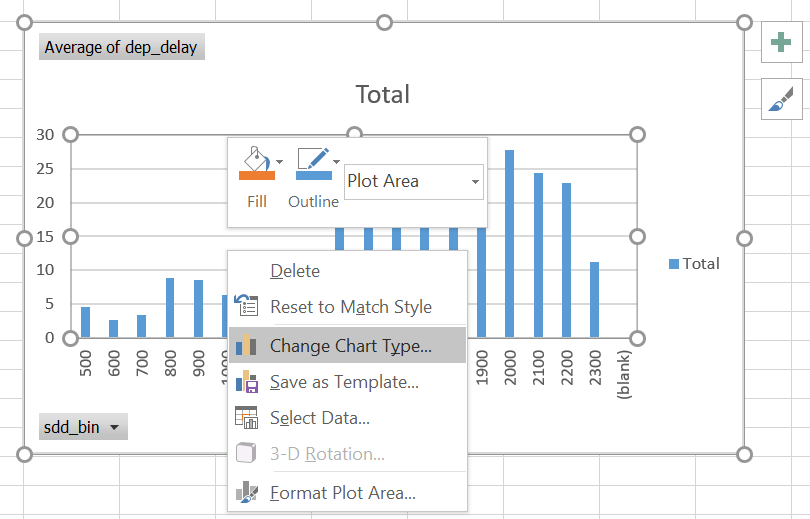

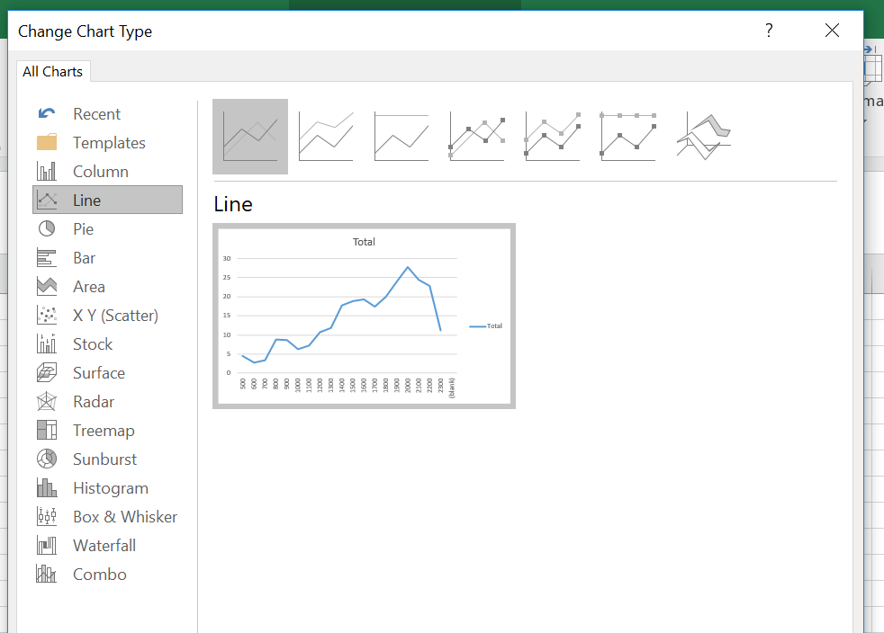

7. You should see that the average departure delay increases later in the day.

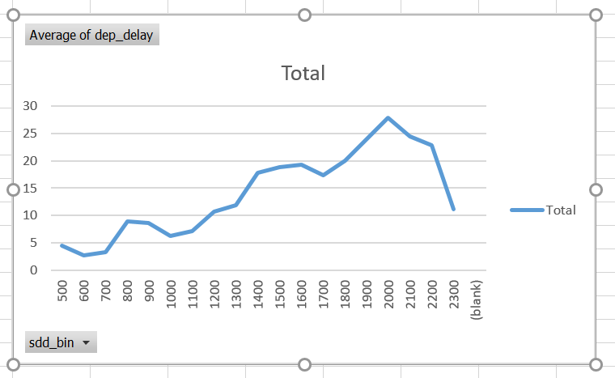

8. Is there a relationship between the number of departing flights, departure time and dep delay?
9. Drag `flight` to the VALUES window and display as Count. Do not remove `dep_delay`!
10. In the plot, right click on the Count of flight data series, select Format Data Series.

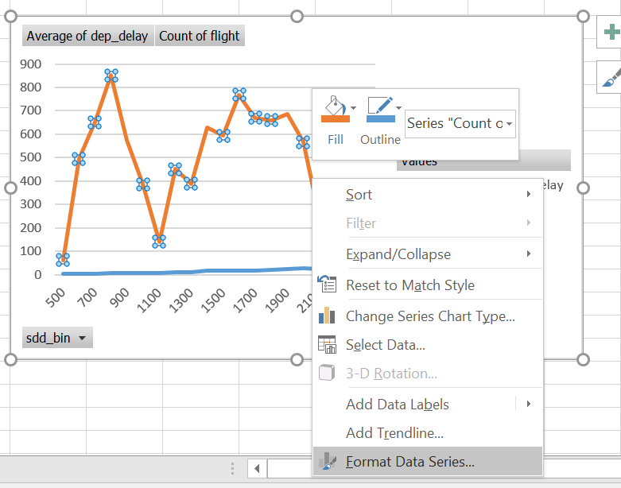

11. At right, Plot Series On Secondary Axis.

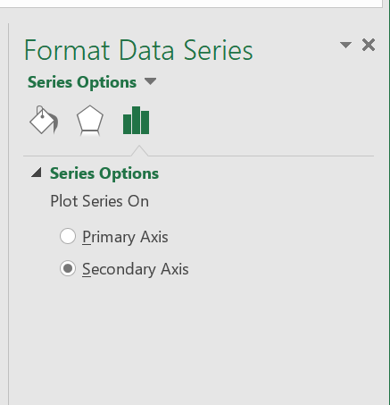

12. You chart should look like this,

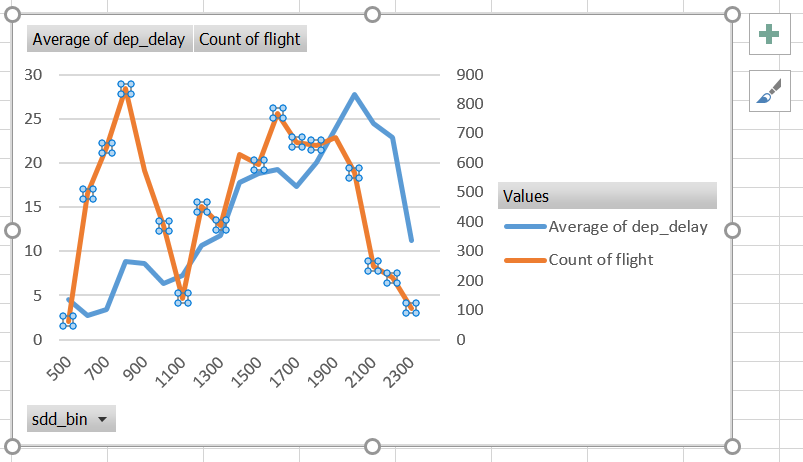

The morning depature rush correlates with a slight average delay time while the evening rush appears to have a stronger correlation.

# Data Filtering NOT Conditional Formatting

Data filtering for the flights data was turned on when it was imported. For other data sets, you can turn on data filtering from the Data tab. Highlight the top row of your data that contains the column names and click the Filter icon at top.

We want to find flights with excessive departure delays before 10:00 AM.

1. Name column `W` `filter1`. Enter all zeroes, `0`, in this column. Do not use `Flash Fill` because it can complicate later steps. You can use `Ctrl + Shift + Down Arrow` to highlight all cells in this row. Then use `Ctrl + C` to copy the zeroes.

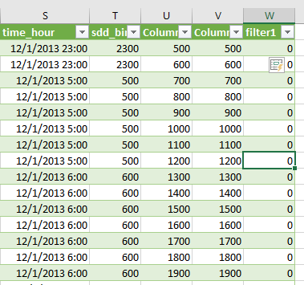

2. Go to `dep_delay` and click the drop down arrow.

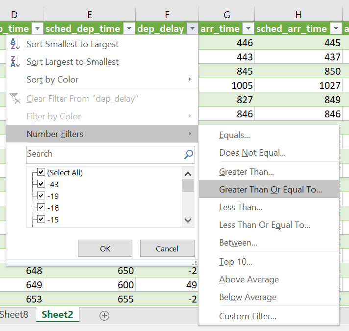

3. Select Number Filters > Greater Than Or Equal To, enter 60 and click OK.

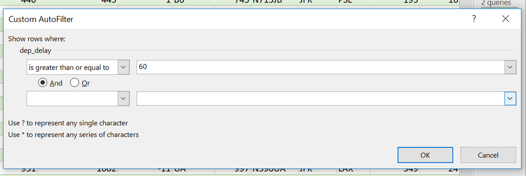

6. Go to `sdd_bin` and click the drop down arrow. Uncheck Select All and select only 500, 600, 700, 800, and 900 and click OK.

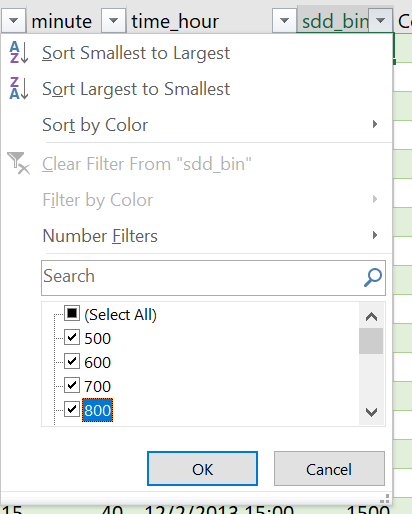

8. Go to the `filter1` column and copy and paste all 1 (ones) into these cells as you did with the zeroes in step 1.

[figure not shown]

9. Go the the dep_delay and sdd_bin columns and Clear Filters.
10. Highlight all cells in the flights data set using the triangle in the upper left corner of the worksheet.
11. Click on Insert > Pivot Table.
12. Drag `carrier` to the AXIS window.
13. Drag `carrier` to the VALUES window.
14. Drag `filter1` to the LEGEND window.
15. Drag `sdd_bin` to FILTERS.

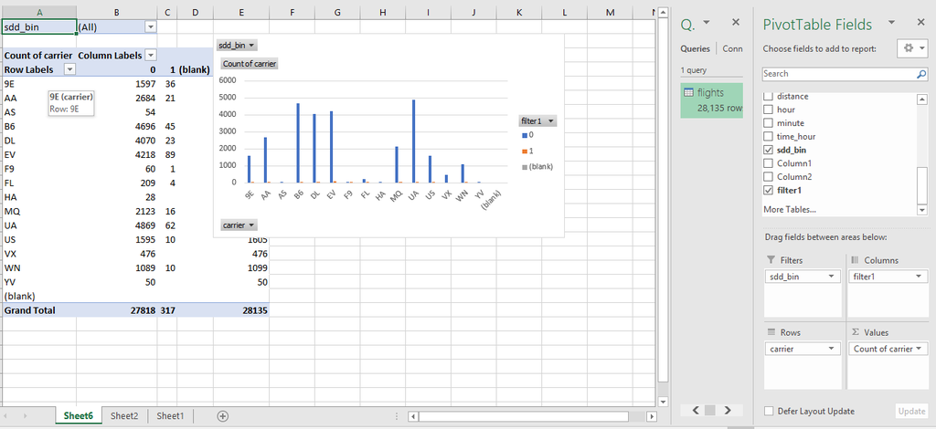

17. Use the `sdd_bin` FILTER to select flights from 500 - 900. This is done in the worksheet area.

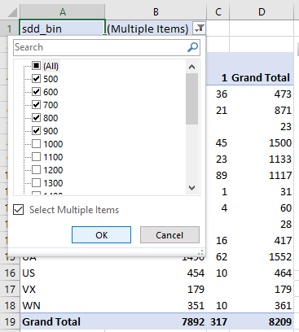

18. Confirm that you have a Clustered Column Chart. Click on the plot area and choose a clustered column chart if necessary.

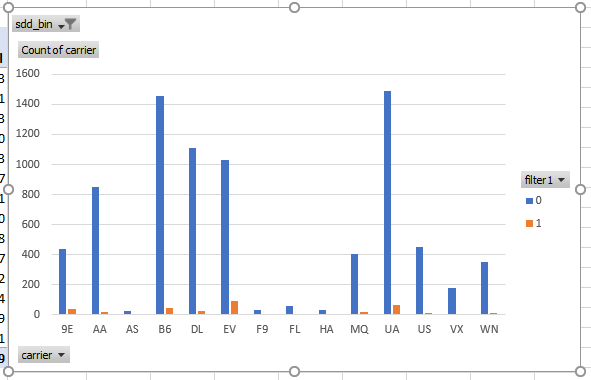

19. Go to VALUES, Click the drop down and choose Value Field Settings. Show value as % of Column Total.

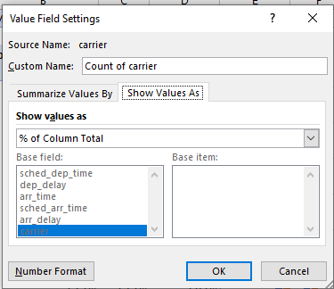

20. Do any carriers seem to have excessive late flights compared to the flights that depart on time?

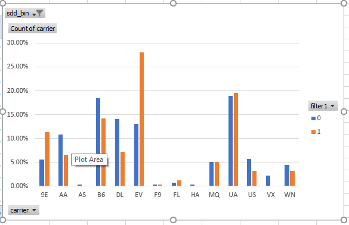

This analysis was done only for the month of December at JFK. Try this analysis with another departure airport or a different month. Do you think that you could include multiple airports in the chart?

# Useful Links

[Excel Functions](https://support.office.com/en-us/article/Excel-functions-alphabetical-b3944572-255d-4efb-bb96-c6d90033e188). An alphabetical list of available functions for Excel with some information on how to use them.

[Excel Cheatsheet](http://www.collegedegreesearch.net/excel-cheats/) - Not comprehensive but a nice cheatsheet for common tasks.

[Excel Pivot Tables](https://support.office.com/en-us/article/create-a-pivottable-to-analyze-worksheet-data-a9a84538-bfe9-40a9-a8e9-f99134456576) - A modest tutorial on Pivot Tables and Charts.

[Disadvantages of Spreadsheets](https://www.denizon.com/spreadsheets/top-10-disadvantages-of-spreadsheets/) - There are likely dozens of documents like this. Simply put, spreadsheets need to be used with caution. They should never be the sole format for your datasets!